# title: “Cariboo Lake Results Draft: Section 3 Temporal Sedimentary Record”

Laminae couplets with thicknesses and grain size greater than 3 standard deviations from the mean were classified as event-based turbidite beds. These layers were observed to have defined beds and were well graded. Where possible the thickness, grain size statistics, and LOI were analyzed for each event layer. However, some layers did not have enough sediment to calculate both LOI and grain size. A more detailed description of the turbidite bed sediment characteristics is provided in the following section.

The basal age for each core is estimated using both the varve chronology and the AMS radiocarbon accumulation rate. The basal age of V1 at a depth of 382 cm is 1622 BP based on the varve chronology and 2046 cal BP, or about a 400 year difference from the extrapolated 14C date. The basal age of V2 at a depth of 291 cm is 1913 BP based on the varve chronology and 2007 cal BP by extrapolating the 14C. Accumulation rates estimated using varve chronology and AMS radiocarbon dates had a larger difference at V1 with 2.4 mm/yr and 1.87 +/- 0.04 mm/yr respectively. Closer agreement was observed at V2 with 1.52 mm/yr estimated by the varve chronology and 1.47 +/- 0.11 mm/yr from the AMS radiocarbon date. While V2 is likely the better predictor of changes in accumulation rates over the last 2000 years, both cores are considered below.

*Event-based Layers*

The turbidite bed grain size, LOI, and thickness shown in Table @ref(tab:turbTbl) illustrates the high sediment flux that occurred during these events compared to the non-event, annually occurring couplets. Increased grain size and varve thickness is observed for event-based layers and reduced LOI. Layer thickness is consistently higher for event-based layers compared to non-event couplets. Grain size and LOI do not show as strong of a response on average across all event-based layers apart from a single event observed at V2 with remarkably high grain size and low LOI around 400 CE (Figure @ref(fig:turbScatter)). Since the primary delivery mechanism of sediment delivery to the core locations is through suspended sediment transport, the size of particle able to be transported even in large sediment flux events is limited. Very few sand grains were observed in any section of either core, however event-based layers were comprised of almost exclusively silt grains compared to the non-event couplets which also had a larger amount of clay. The composition of sediment grains within the event-based layers were all characterized by a single mode with less than 0.01% clay, over 98% silt and less than 1% sand. The grain size distribution for the non-event couplet sediments is characterized by a bi-modal distribution with an average composition of 16% clay, 83% silt, and 1%. The average D50 grain size of the event layers is 9.7 µm and 16.2 µm for V1 and V2 respectively and for couplet sediment is 7.6 µm and 6.4 µm for V1 and V2 respectively.

Figure @ref(fig:turbScatter), shows the timing of the event-based layers between V1 and V2. Four of the event layers at V1 and V2 coincide according to their layer thickness. Coincident measurements of grain size are provided for three of the seven event layers and no coincident measurements of LOI are provided between V1 and V2 due to the lack of sample material. The coincident layers observed around 750, 1250, 1600, and 1950 CE at both V1 and V2 are inferred to be from very large lake-wide events such as large slope failures upstream of both cores, unusually high flows during the spring freshet, or rain on snow events in the early fall delivering high sediment-yield across the lake leading to some coincident event layers at both cores. The temporally separated layers observed at ~250 CE at V1 and ~400 and ~1245 CE at V2 may be from isolated events such as from local hillslope failures, subaqueous side-wall slumps and/or very local tributary stream floods. Event-based layers, shown in Figure @ref(fig:turbScatter) were removed in subsequent trend analyses of varve thickness, grain size, and percent organics.

Sediment characteristics of turbidite beds for V1 and V2. The “event_mean” is the mean sediment characteristic for the group, “event_sd” is the standard deviation for the group, and “event_n” is the number of layers analyzed in each group.

| core | metric | non_event_mean | event_mean | event_sd | event_n |
| --- | --- | --- | --- | --- | --- |
| V1 | D50 (µm) | 7.64 | 9.68 | 0.80 | 5 |
| V2 | D50 (µm) | 6.35 | 16.20 | 9.40 | 6 |
| V1 | LOI (%) | 4.75 | 4.67 | 0.53 | 3 |
| V2 | LOI (%) | 4.80 | 2.86 | 0.94 | 4 |
| V1 | Thickness (mm) | 2.40 | 10.32 | 4.24 | 5 |
| V2 | Thickness (mm) | 1.51 | 11.17 | 15.89 | 7 |

[figure not shown]

Timing and Standardized Departures of turbidite thickness, grain size, and LOI for V1 and V2. Year (CE) is the estimated year using linear interpolation from the AMS radiocarbon dates.

*Sediment Yield Statistics*

The mean varve thickness with event-based layers removed for V1 is 2.4 mm compared to V2 which is 1.5 mm. Higher varve thickness is expected at V1 due to its closer proximity to the Cariboo River delta. Figure @ref(fig:varves-a) shows the time series of varve thickness measured from V1 and V2 and illustrates trends in suspended sediment delivery to Cariboo Lake. The measured couplet thicknesses in the two cores are plotted as standardized departures to facilitate comparison between the two cores. In each plot a 30-year moving average with a 1-year time step is plotted in black to emphasize decadal to centennial patterns in accumulation rate departures. Chronologies in Figure @ref(fig:varves-a) assume a linear interpolation from the single AMS radiocarbon dates.

At V1, the 30-year average varve thickness remains above average from 0 to 750 CE, for both V1 and V2, with a stronger signal observed for V1 which is closer to the main Cariboo River outlet. Below average varve thickness is observed at both V1 and V2 from 750-1600 CE. After 1600 CE, trends in varve thickness between the two cores depart, with V2 above average during the Little Ice Age and V1 remains below average. Sub-centennial trends are not reported due to the coarse temporal control for both V1 and V2.

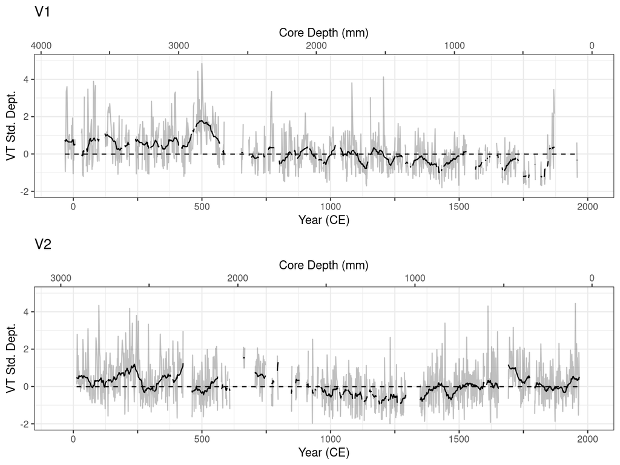

Standardized departure from the mean varve thickness for cores V1 and V2. The gray lines represent measured varve thickness at an annual resolution where available, the black line is a 30-year moving average, gaps correspond to portions of the core that did not have discernible varves. The bottom axes, labelelled Year (CE), was estimated using linear interpolation from the AMS radiocarbon dates.

*Grain Size*